# La altura de los niños ¿afecta el rendimiento intelectual?

Czernikier Alejandro, Lisa Fernando

2024-11-16

```r
# Instalar las librerías necesarias si aún no lo están
if (!require("tidyverse")) install.packages("tidyverse")
# Cargar la librería tidyverse
library(tidyverse)
library(tidyr)
library(dplyr)
```

## Cargamos el Dataset

```r
# Cargar el archivo .csv ya modificado
# dataset creado tomando como base otro dataset (ver ref)
# y realizando modificaciones
ds <- read.csv("score_pais.csv")

summary(ds)
```

```
##    testScore          height        country              city
##  Min.   :  0.00   Min.   :102.3   Length:480         Length:480
##  1st Qu.: 32.60   1st Qu.:131.8   Class :character   Class :character
##  Median : 51.00   Median :142.9   Mode  :character   Mode  :character
##  Mean   : 50.39   Mean   :141.3
##  3rd Qu.: 67.51   3rd Qu.:153.1
##  Max.   :100.00   Max.   :176.4
```

```r
unique(ds$country)
```

```
## [1] "Nepal"     "Jamaica"   "Argentina" "UK"        "Singapur"  "Guatemala"
## [7] "PBajos"    "Estonia"
```

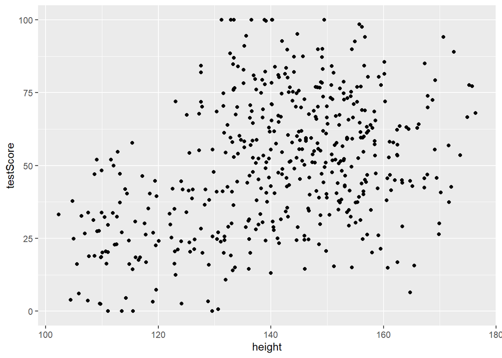

```r
(prelim_plot <- ggplot(ds, aes(x = height, y = testScore)) +
  geom_point())
```

# Modelo lineal simple

Fiteamos un modelo lineal ignorando los países

```r
modlineal <- lm(testScore ~ height, data = ds)
```

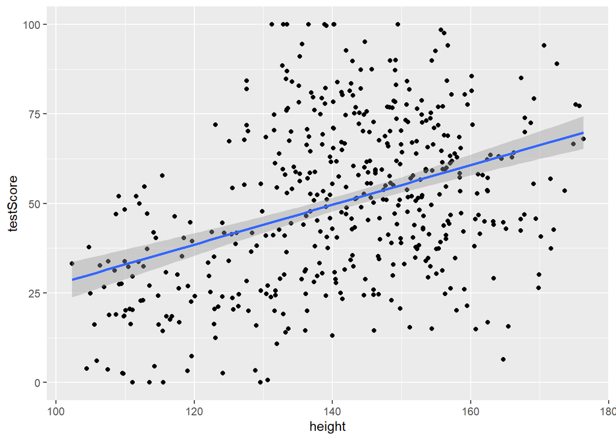

```r
(prelim_plot <- ggplot(ds, aes(x = height, y = testScore)) +
  geom_point() +
  geom_smooth(method = "lm"))
```

```r
summary(modlineal)
```

```
##
## Call:
## lm(formula = testScore ~ height, data = ds)
##
## Residuals:
##     Min      1Q  Median      3Q     Max
## -56.962 -16.411  -0.783  15.193  55.200
##
## Coefficients:
##              Estimate Std. Error t value Pr(>|t|)
## (Intercept) -28.02581    8.49852  -3.298  0.00105 **
## height        0.55487    0.05975   9.287  < 2e-16 ***
## ---
## Signif. codes:  0 '***' 0.001 '**' 0.01 '*' 0.05 '.' 0.1 ' ' 1
##
## Residual standard error: 21.2 on 478 degrees of freedom
## Multiple R-squared:  0.1529, Adjusted R-squared:  0.1511
## F-statistic: 86.25 on 1 and 478 DF,  p-value: < 2.2e-16
```

Según lo que se puede ver del summary y en el gráfico, parecería que los chicos mas altos son mas inteligentes. Algo extraño, la inteligencia no depende de la altura de la persona.

Veamos si se cumplen los supuestos

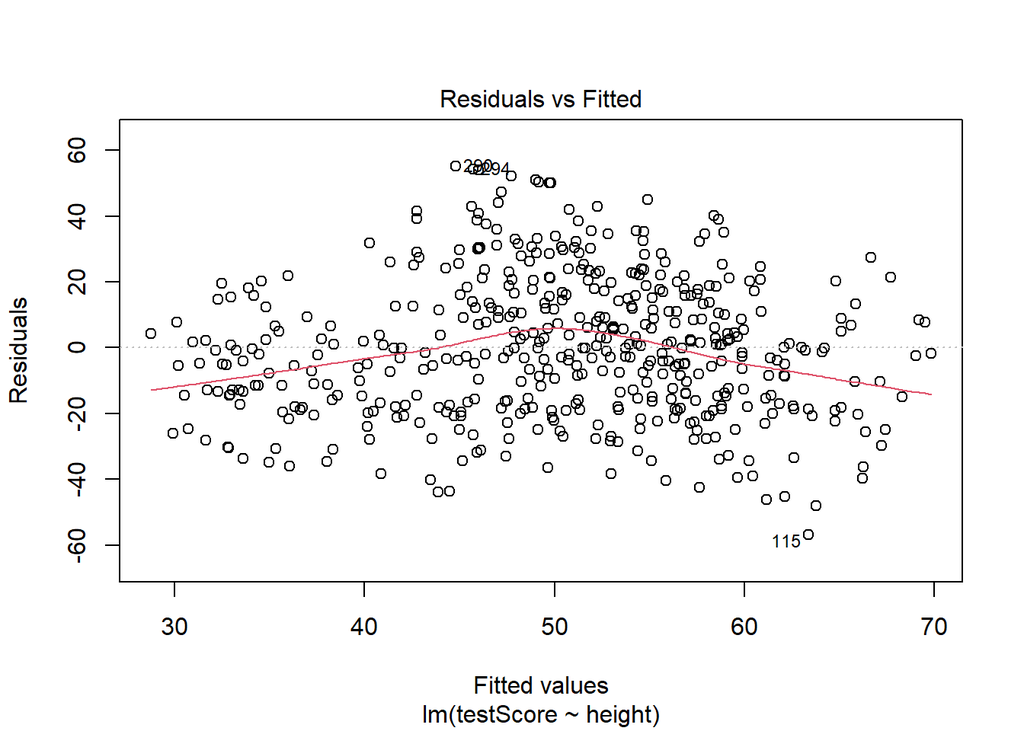

```r
plot(modlineal, which = 1)
```

No parece que haya una heterosedastidicad muy marcada

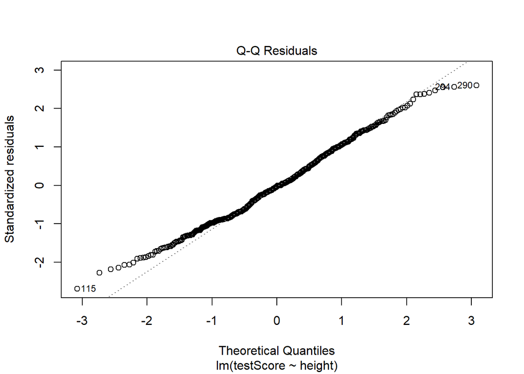

```r
plot(modlineal, which = 2)
```

Si bien se desvía un poco en los extremos no parece ser nada grave

Ahora bien, respecto a independencia de los datos, tenemos información de distintos países. Cabe la posibilidad de que los datos que corresponden a un mismo país sean muy parecidos entre si, y diferentes al resto, es decir que haya cierta correlación.

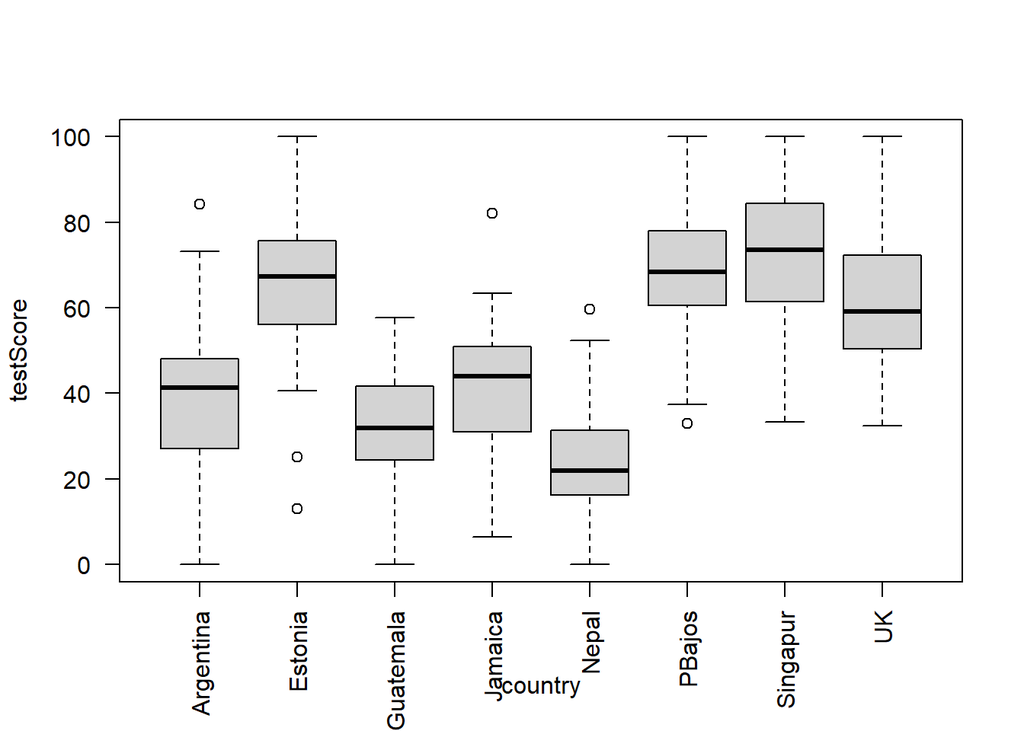

```r
boxplot(testScore ~ country, data = ds, las = 2)
```

```r
colour_plot <- ggplot(ds, aes(x = height, y = testScore, colour = country)) +
  geom_point(size = 2) +
  theme_classic() +
  labs(colour = "Country")  # Cambia el título de la leyenda
theme(legend.position = "bottom")
```

```
## List of 1
##  $ legend.position: chr "bottom"
##  - attr(*, "class")= chr [1:2] "theme" "gg"
##  - attr(*, "complete")= logi FALSE
##  - attr(*, "validate")= logi TRUE
```

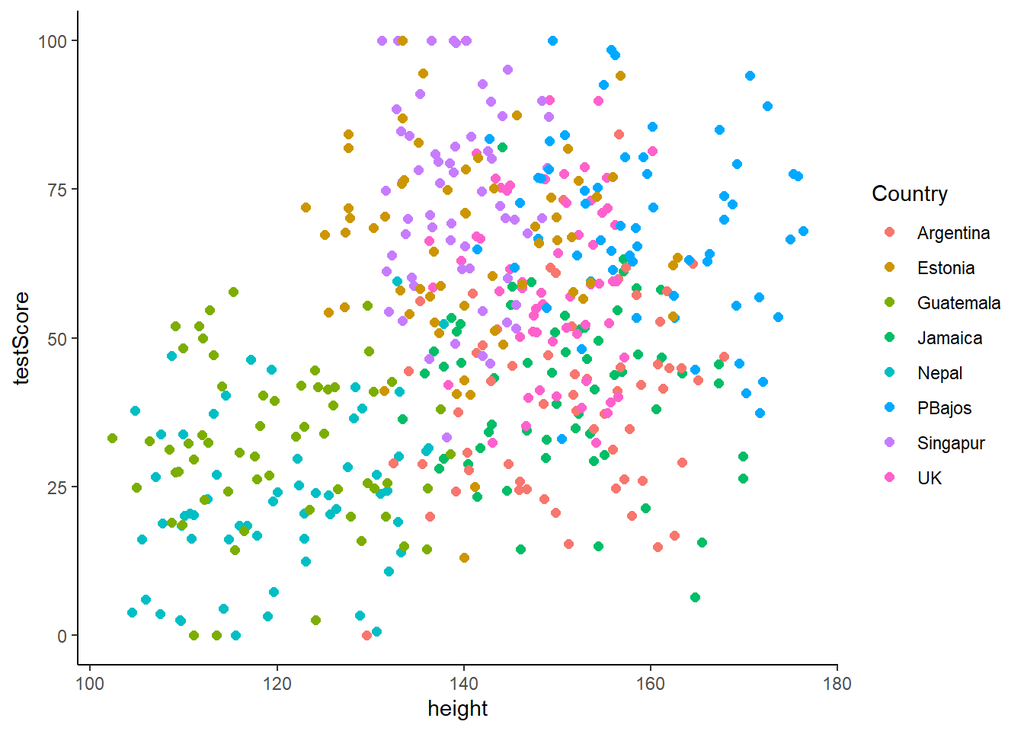

```r
colour_plot
```

Del gráfico parecería que tanto las alturas como los scores están agrupados por países. No se cumple independencia.

## Análisis Multiples

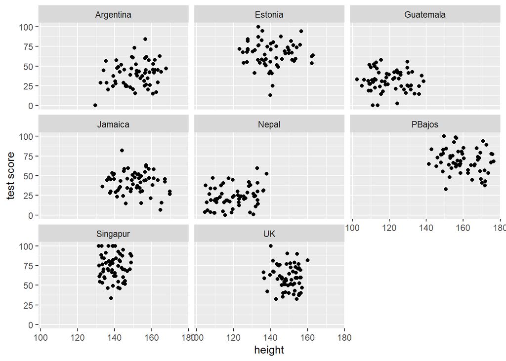

```r
(split_plot <- ggplot(aes(height, testScore), data = ds) +
  geom_point() +
  facet_wrap(~ country) +
  xlab("height") +
  ylab("test score"))
```

Ahora bien, serian ocho análisis diferentes, y si tomamos en cuenta que para cada país hay datos de 3 ciudades diferentes, que probablemente ocurra lo mismo, tendríamos que hacer en total 24 análisis. Estamos hablando de 48 parámetros (b y m) en total, y están quedando solo 20 niños por ciudad. El problema esta en que estamos reduciendo drasticamente el tamaño de la muestra y al realizar tantos ajustes aumentamos la chance de rechazar la hipótesis nula cuando no deberíamos.

Para poder usar todos los datos, pero aun así tener en cuenta la variación que genera cada país podemos usar un modelo lineal sumando la columna.

## Modelo lineal multiple

```r
modLineal_pais <- lm(testScore ~ height + country, data = ds)
summary(modLineal_pais)
```

```
##
## Call:
## lm(formula = testScore ~ height + country, data = ds)
##
## Residuals:
##     Min      1Q  Median      3Q     Max
## -52.263  -9.926   0.361   9.994  44.488
##
## Coefficients:
##                   Estimate Std. Error t value Pr(>|t|)
## (Intercept)       37.80012   12.20339   3.098  0.00207 **
## height             0.01267    0.07974   0.159  0.87379
## countryEstonia    25.76919    2.85435   9.028  < 2e-16 ***
## countryGuatemala  -7.68962    3.69867  -2.079  0.03816 *
## countryJamaica     1.53856    2.73149   0.563  0.57352
## countryNepal     -16.20923    3.69665  -4.385 1.43e-05 ***
## countryPBajos     28.90546    2.81624  10.264  < 2e-16 ***
## countrySingapur   33.67210    2.88964  11.653  < 2e-16 ***
## countryUK         20.37354    2.73522   7.449 4.54e-13 ***
## ---
## Signif. codes:  0 '***' 0.001 '**' 0.01 '*' 0.05 '.' 0.1 ' ' 1
##
## Residual standard error: 14.96 on 471 degrees of freedom
## Multiple R-squared:  0.5843, Adjusted R-squared:  0.5773
## F-statistic: 82.76 on 8 and 471 DF,  p-value: < 2.2e-16
```

Ahora la altura deja de ser significativa. Pero hay una vuelta de tuerca mas. Con este modelo estamos estimando la variación del testscore entre cada país.

Pero a nosotros no nos interesa cuantificar cuanto cambia el score para cada país en especifico. Estamos buscando saber si la altura del chico afecta el score independientemente de que país sea.

# Modelo mixto

Acá es donde entra en juego el modelo mixto. Permite usar todos los datos y tener en cuenta las correlaciones entre datos que vienen del mismo país.

```r
library(lme4)
```

Ahora cuales de las variables son efectos fijos y cuales aleatorios?

En nuestro caso, estamos interesados en ver si la altura de un chico impacta en la inteligencia. Por lo tanto la altura es una variable fija.

Con recursos y tiempo ilimitados pordriamos muestrear todos los niños de todos los países del mundo, pero queremos generalizar basándonos en una muestra representativa.

No nos interesa saber (en este caso) que tan mejores son los chicos del país A comparados con los chicos del país B, pero sabemos que los sistemas educativos de cada país pueden tener distinta calidad llevando a que los scores sean diferentes, y queremos saber cuanta variación es atribuible a esto cuando queremos predecir el score de un chico del país Z.

Ajustamos el nuevo modelo

```r
modMixto <- lmer(testScore ~ height + (1|country), data = ds)
summary(modMixto)
```

```
## Linear mixed model fit by REML ['lmerMod']
## Formula: testScore ~ height + (1 | country)
##    Data: ds
##
## REML criterion at convergence: 3991.2
##
## Scaled residuals:
##     Min      1Q  Median      3Q     Max
## -3.4815 -0.6513  0.0066  0.6685  2.9583
##
## Random effects:
##  Groups   Name        Variance Std.Dev.
##  country  (Intercept) 339.7    18.43
##  Residual             223.8    14.96
## Number of obs: 480, groups:  country, 8
##
## Fixed effects:
##             Estimate Std. Error t value
## (Intercept) 45.69928   12.90145   3.542
## height       0.03316    0.07865   0.422
##
## Correlation of Fixed Effects:
##        (Intr)
## height -0.861
```

Del summary, efectos fijos, podemos ver que el error es mayor al coeficiente que acompaña la variable altura, por lo que no es distinguible de cero.

Y también podemos ver de la parte de efectos aleatorios, que la varianza explicada por la variable país es aprox el 60% del total (340/(340+224)). Tener en cuenta que esta varianza es la que queda luego de haber ajustado el modelo con los efectos fijos.

## Cumplimiento de supuestos

Vamos a ver si los supuestos se cumplen

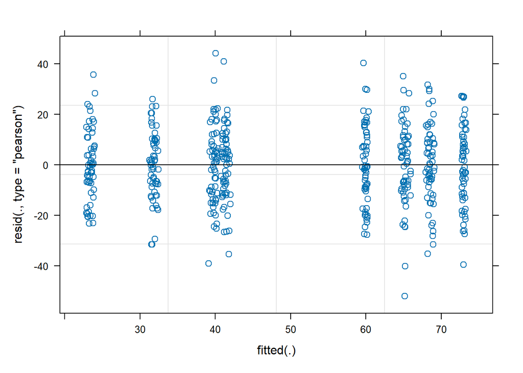

```r
plot(modMixto)
```

No parece haber patrones.

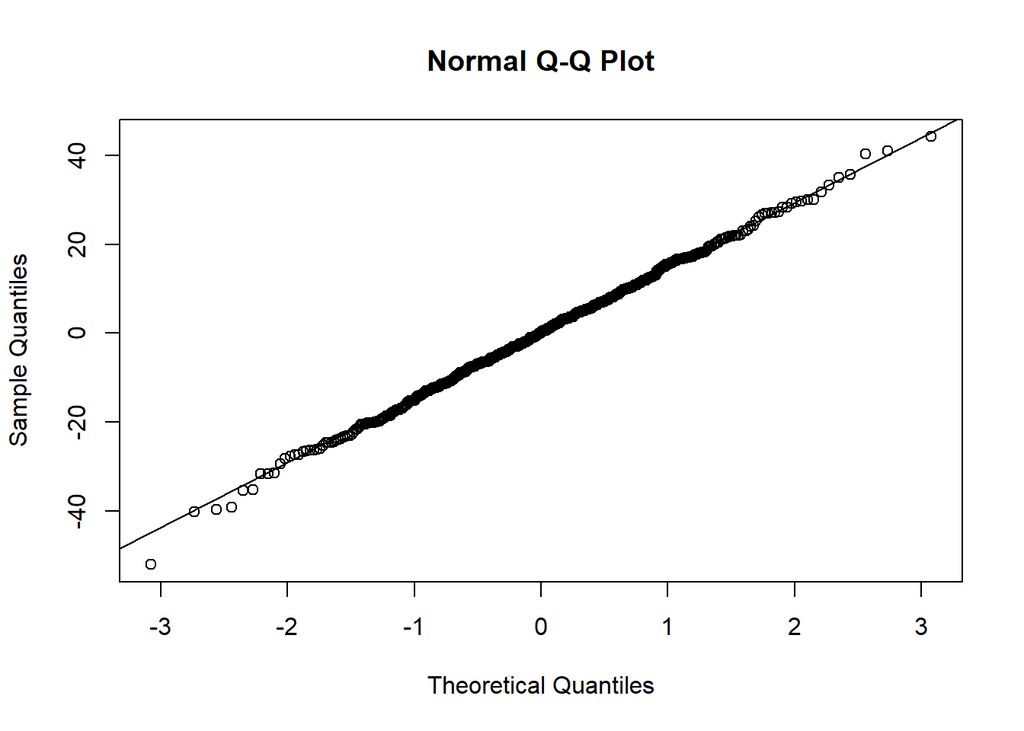

```r
qqnorm(resid(modMixto))
qqline(resid(modMixto))
```

Ahora bien, hasta aca el modelo mixto que planteamos solo distingue los interceptos, pero la pendiente es la misma para todos los casos.

## Modelo mixto con pendientes diferentes

Si se quisiera dejar libre tanto el intercepto como la pendiente para cada pais la sintaxis seria la siguiente

```r
# Ajustar el modelo mixto
modMixto2 <- lmer(testScore ~ height + (1 + height | country), data = ds)
```

```
## boundary (singular) fit: see help('isSingular')
```

# Resultados

## Modelo mixto (intercept)

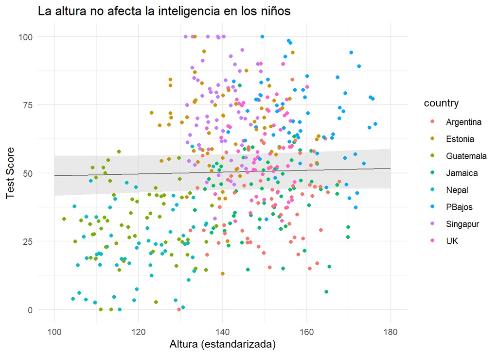

```r
library(ggeffects)  # install the package first if you haven't already, then load it

# Extract the prediction data frame
pred.mm <- ggpredict(modMixto, terms = c("height"))

# Plot the predictions

(ggplot(pred.mm) +
   geom_line(aes(x = x, y = predicted)) +
   geom_ribbon(aes(x = x, ymin = predicted - std.error, ymax = predicted + std.error),
               fill = "lightgrey", alpha = 0.5) +
   geom_point(data = ds,
              aes(x = height, y = testScore, colour = country)) +
   labs(x = "Altura (estandarizada)", y = "Test Score",
        title = "La altura no afecta la inteligencia en los niños") +
   theme_minimal()
)
```

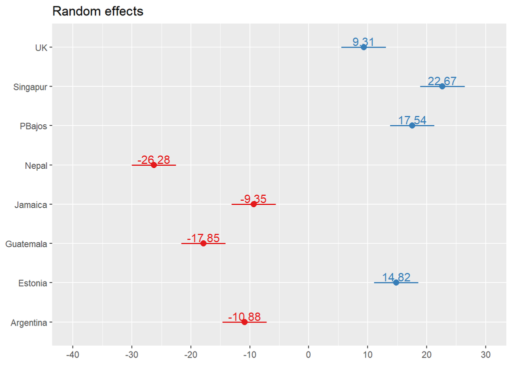

```r
library(sjPlot)

# Visualizamos los efectos aleatorios
(re.effects <- plot_model(modMixto, type = "re", show.values = TRUE))
```

```r
# show summary
summary(modMixto)
```

```
## Linear mixed model fit by REML ['lmerMod']
## Formula: testScore ~ height + (1 | country)
##    Data: ds
##
## REML criterion at convergence: 3991.2
##
## Scaled residuals:
##     Min      1Q  Median      3Q     Max
## -3.4815 -0.6513  0.0066  0.6685  2.9583
##
## Random effects:
##  Groups   Name        Variance Std.Dev.
##  country  (Intercept) 339.7    18.43
##  Residual             223.8    14.96
## Number of obs: 480, groups:  country, 8
##
## Fixed effects:
##             Estimate Std. Error t value
## (Intercept) 45.69928   12.90145   3.542
## height       0.03316    0.07865   0.422
##
## Correlation of Fixed Effects:
##        (Intr)
## height -0.861
```

```r
library(stargazer)
stargazer(modMixto, type = "text",
          digits = 2,
          star.cutoffs = c(0.05, 0.01, 0.001),
          digit.separator = "")
```

```
##
## =================================================
##                          Dependent variable:
##                     -----------------------------
##                               testScore
## -------------------------------------------------
## height                          0.03
##                                (0.08)
##
## Constant                      45.70***
##                                (12.90)
##
## -------------------------------------------------
## Observations                     480
## Log Likelihood                -1995.60
## Akaike Inf. Crit.              3999.20
## Bayesian Inf. Crit.            4015.90
## =================================================
## Note:               *p<0.05; **p<0.01; ***p<0.001
```

Si quisiéramos reportar el R2, en modelos mixtos tenemos dos métricas diferentes

```r
library(MuMIn)

# Calcular R2 marginal y condicional
r2 <- r.squaredGLMM(modMixto)
print(r2)
```

```
##               R2m       R2c
## [1,] 0.0005127892 0.6030072
```

El R2m (marginal) es la proporción de varianza explicada solo por efectos fijos, mientras que el R2c(condicional) es la proporción de la varianza explicada por los efectos fijos y aleatorios

## Modelo Mixto (intercept + slope)

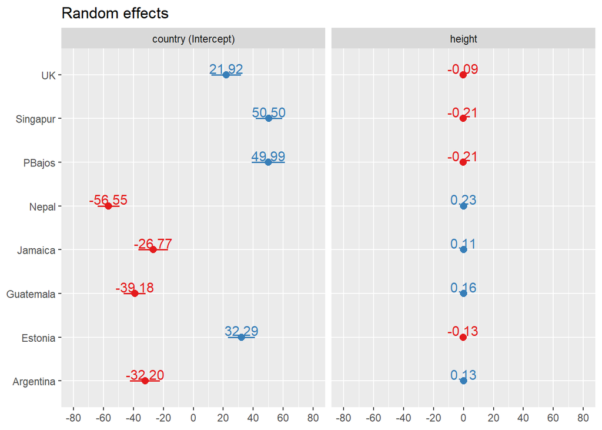

```r
# Visualizamos los efectos aleatorios
(re.effects <- plot_model(modMixto2, type = "re", show.values = TRUE))
```

```r
# show summary
summary(modMixto2)
```

```
## Linear mixed model fit by REML ['lmerMod']
## Formula: testScore ~ height + (1 + height | country)
##    Data: ds
##
## REML criterion at convergence: 3986.1
##
## Scaled residuals:
##     Min      1Q  Median      3Q     Max
## -3.4980 -0.6667  0.0174  0.6635  2.9451
##
## Random effects:
##  Groups   Name        Variance  Std.Dev. Corr
##  country  (Intercept) 1.748e+03 41.8059
##           height      3.012e-02  0.1736  -1.00
##  Residual             2.219e+02 14.8951
## Number of obs: 480, groups:  country, 8
##
## Fixed effects:
##              Estimate Std. Error t value
## (Intercept) 5.155e+01  1.853e+01   2.782
## height      7.645e-04  9.921e-02   0.008
##
## Correlation of Fixed Effects:
##        (Intr)
## height -0.966
## optimizer (nloptwrap) convergence code: 0 (OK)
## boundary (singular) fit: see help('isSingular')
```

```r
stargazer(modMixto2, type = "text",
          digits = 2,
          star.cutoffs = c(0.05, 0.01, 0.001),
          digit.separator = "")
```

```
##
## =================================================
##                          Dependent variable:
##                     -----------------------------
##                               testScore
## -------------------------------------------------
## height                          0.001
##                                (0.10)
##
## Constant                       51.55**
##                                (18.53)
##
## -------------------------------------------------
## Observations                     480
## Log Likelihood                -1993.07
## Akaike Inf. Crit.              3998.14
## Bayesian Inf. Crit.            4023.19
## =================================================
## Note:               *p<0.05; **p<0.01; ***p<0.001
```

```r
# Calcular R2 marginal y condicional
r2 <- r.squaredGLMM(modMixto2)
print(r2)
```

```
##               R2m       R2c
## [1,] 2.907393e-07 0.5800673
```

## Comparamos ambos modelos mixtos

Akaike Information Criterion (AIC): Penaliza la complejidad del modelo y favorece modelos más simples.Un valor más bajo indica un modelo mejor ajustado.

Bayesian Information Criterion (BIC): Similar al AIC, pero penaliza más severamente los modelos con demasiados parámetros. Al igual que el AIC, valores más bajos son preferibles.

```r
# Extraer AIC y BIC de ambos modelos
model_comparison <- data.frame(
  Model = c("modMixto", "modMixto2"),
  AIC = c(AIC(modMixto), AIC(modMixto2)),
  BIC = c(BIC(modMixto), BIC(modMixto2))
)

# Mostrar la tabla
print(model_comparison)
```

```
##       Model      AIC      BIC
## 1  modMixto 3999.203 4015.898
## 2 modMixto2 3998.143 4023.186
```

De la tabla podemos ver que ambos modelos performan de manera muy similar, los AIC son prácticamente iguales y el BIC favorece un poco al modelo mixto de intercepto solamente. Tiene sentido ya que la pendiente (altura) no influye en nuestra variable a explicar.

Para este ejemplo no tendría sentido comparar la performance con el modelo lineal simple ya que la conclusión o explicación que se puede sacar de los dos tipos de modelo es completamente diferente.

# Referencias

https://gkhajduk.d.pr/9GPn/3nbbPoK6 (dataset original)

https://fhernanb.github.io/libro_modelos_mixtos/

https://www.ibm.com/docs/es/spss-statistics/25.0.0?topic=SSLVMB_25.0.0/spss/advanced/idh_mixl.htm

https://gkhajduk.github.io/2017-03-09-mixed-models/

https://es.wikipedia.org/wiki/Anexo:Pa%C3%ADses_por_estatura_media

https://es.wikipedia.org/wiki/Informe_PISA